# Function3.Rmd

jharner

June 2, 2015

## 6.3 Every operation is a function call

The previous example of redefining ( works because every operation in R is a function call, whether or not it looks like one. This includes infix operators like `+`, control flow operators like `for`, `if`, and `while`, subsetting operators like `[]` and `$`, and even the curly brace `{`. This means that each pair of statements in the following example is exactly equivalent. Note that `’`, the backtick, lets you refer to functions or variables that have otherwise reserved or illegal names:

```r
x <- 10; y <- 5
x + y
```

```
## [1] 15
```

```r
`+`(x, y)
```

```
## [1] 15
```

```r
for (i in 1:2) print(i)
```

```
## [1] 1
## [1] 2
```

```r
`for`(i, 1:2, print(i))
```

```
## [1] 1
## [1] 2
```

```r
if (i == 1) print("yes!") else print("no.")
```

```
## [1] "no."
```

```r
`if`(i == 1, print("yes!"), print("no."))
```

```
## [1] "no."
```

```r
x[3]
```

```
## [1] NA
```

```r
`[`(x, 3)
```

```
## [1] NA
```

```r
{ print(1); print(2); print(3) }
```

```
## [1] 1
## [1] 2
## [1] 3
```

```r
`{`(print(1), print(2), print(3))
```

```
## [1] 1
## [1] 2
## [1] 3
```

It is possible to override the definitions of these special functions, but this is generally a bad idea. However, there are occasions when it might be useful. Domain specific languages use this idea to create domain specific languages that allow you to concisely express new concepts using existing R constructs.

It’s more often useful to treat special functions as ordinary functions. For example, we could use `sapply()` to add 3 to every element of a list by first defining a function `add()`:

```r
add <- function(x, y) x + y
sapply(1:10, add, 3)
```

```
##  [1]  4  5  6  7  8  9 10 11 12 13
```

We can also get the same effect using the built-in + function.

```r
sapply(1:5, `+`, 3)
```

```
## [1] 4 5 6 7 8
```

```r
sapply(1:5, "+", 3)
```

```
## [1] 4 5 6 7 8
```

Note the difference between `+` and `"+"`. The first one is the value of the object called `+`, and the second is a string containing the character `+`. The second version works because sapply can be given the name of a function instead of the function itself: if you read the source of `sapply()`, you’ll see the first line uses `match.fun()` to find functions given their names.

A more useful application is to combine lapply() or sapply() with subsetting:

```r
x <- list(1:3, 4:9, 10:12)
x
```

```
## [[1]]
## [1] 1 2 3
##
## [[2]]
## [1] 4 5 6 7 8 9
##
## [[3]]
## [1] 10 11 12
```

```r
sapply(x, "[", 2)
```

```
## [1]  2  5 11
```

```r
# equivalent to
sapply(x, function(x) x[2])
```

```
## [1]  2  5 11
```

## 6.4 Function arguments

It’s useful to distinguish between the **formal arguments** and the **actual arguments** of a function. The formal arguments are a property of the function, whereas the actual or calling arguments can vary each time you call the function. This section discusses:  
* how calling arguments are mapped to formal arguments,  
* how you can call a function given a list of arguments,  
* how default arguments work, and the impact of lazy evaluation.

### 6.4.1 Calling functions

When calling a function you can specify arguments by:  
* position,  
* complete name,  
* partial name.  
Arguments are matched first by:  
* exact name (perfect matching),  
* then by prefix matching, and  
* finally by position.

```r
f <- function(abcdef, bcde1, bcde2) {
  list(a = abcdef, b1 = bcde1, b2 = bcde2)
}
str(f(1, 2, 3))
```

```
## List of 3
##  $ a : num 1
##  $ b1: num 2
##  $ b2: num 3
```

```r
str(f(2, 3, abcdef = 1))
```

```
## List of 3
##  $ a : num 1
##  $ b1: num 2
##  $ b2: num 3
```

```r
# Can abbreviate long argument names:
str(f(2, 3, a = 1))
```

```
## List of 3
##  $ a : num 1
##  $ b1: num 2
##  $ b2: num 3
```

```r
# But this doesn't work because abbreviation is ambiguous
# str(f(1, 3, b = 1))
```

```
#> Error in f(1, 3, b = 1): argument 3 matches multiple formal arguments
```

Generally, you only want to use positional matching for the first one or two arguments; they will be the most commonly used, and most readers will know what they are. Avoid using positional matching for less commonly used arguments, and only use readable abbreviations with partial matching. Named arguments should always come after unnamed arguments. If a function uses `...`, you can only specify arguments listed after `...` with their full name.

These are good calls:

```r
mean(1:10)
```

```
## [1] 5.5
```

```r
mean(1:10, trim = 0.05)
```

```
## [1] 5.5
```

This is probably overkill:

```r
mean(x = 1:10)
```

```
## [1] 5.5
```

And these are just confusing:

```r
mean(1:10, n = T)
```

```
## [1] 5.5
```

```r
mean(1:10, , FALSE)
```

```
## [1] 5.5
```

```r
mean(1:10, 0.05)
```

```
## [1] 5.5
```

```r
mean(, TRUE, x = c(1:10, NA))
```

```
## [1] 5.5
```

### 6.4.2 Calling a function given a list of arguments

Suppose you had a list of function arguments:

```r
args <- list(1:10, na.rm = TRUE)
```

How could you then send that list to `mean()`? You need `do.call()`:

```r
do.call(mean, list(1:10, na.rm = TRUE))
```

```
## [1] 5.5
```

```r
# Equivalent to
mean(1:10, na.rm = TRUE)
```

```
## [1] 5.5
```

### 6.4.3 Default and missing arguments

Function arguments in R can have default values.

```r
f <- function(a = 1, b = 2) {
  c(a, b)
}
f()
```

```
## [1] 1 2
```

Since arguments in R are evaluated lazily, the default value can be defined in terms of other arguments:

```r
g <- function(a = 1, b = a * 2) {
  c(a, b)
}
g()
```

```
## [1] 1 2
```

```r
g(10)
```

```
## [1] 10 20
```

Default arguments can even be defined in terms of variables created within the function. This is used frequently in base R functions, but I think it is bad practice, because you can’t understand what the default values will be without reading the complete source code.

```r
h <- function(a = 1, b = d) {
  d <- (a + 1) ^ 2
  c(a, b)
}
h()
```

```
## [1] 1 4
```

```r
h(10)
```

```
## [1]  10 121
```

You can determine if an argument was supplied or not with the `missing()` function.

```r
i <- function(a, b) {
  c(missing(a), missing(b))
}
i()
```

```
## [1] TRUE TRUE
```

```r
i(a = 1)
```

```
## [1] FALSE  TRUE
```

```r
i(b = 2)
```

```
## [1]  TRUE FALSE
```

```r
i(1, 2)
```

```
## [1] FALSE FALSE
```

Sometimes you want to add a non-trivial default value, which might take several lines of code to compute. Instead of inserting that code in the function definition, you could use `missing()` to conditionally compute it if needed. Instead, I usually set the default value to `NULL` and use `is.null()` to check if the argument was supplied.

### 6.4.4 Lazy evaluation

By default, R function arguments are lazy, i.e., they’re only evaluated if they’re actually used:

```r
f <- function(x) {
  10
}
f(stop("This is an error!"))
```

```
## [1] 10
```

If you want to ensure that an argument is evaluated you can use force():

```r
f <- function(x) {
  force(x)
  10
}
# f(stop("This is an error!"))
```

```
#> Error in force(x): This is an error!
```

This is important when creating closures with `lapply()` or a `loop`:

```r
add <- function(x) {
  function(y) x + y
}
adders <- lapply(1:10, add)
adders
```

```
## [[1]]
## function (y)
## x + y
## <environment: 0x324cb88>
##
## [[2]]
## function (y)
## x + y
## <environment: 0x324ca00>
##
## [[3]]
## function (y)
## x + y
## <environment: 0x324c878>
##
## [[4]]
## function (y)
## x + y
## <environment: 0x324c6f0>
##
## [[5]]
## function (y)
## x + y
## <environment: 0x324c568>
##
## [[6]]
## function (y)
## x + y
## <environment: 0x324db08>
##
## [[7]]
## function (y)
## x + y
## <environment: 0x324d980>
##
## [[8]]
## function (y)
## x + y
## <environment: 0x324d7f8>
##
## [[9]]
## function (y)
## x + y
## <environment: 0x324d670>
##
## [[10]]
## function (y)
## x + y
## <environment: 0x324d4e8>
```

```r
adders[[1]](10)
```

```
## [1] 20
```

```r
adders[[10]](10)
```

```
## [1] 20
```

`x` is lazily evaluated the first time that you call one of the adder functions. At this point, the loop is complete and the final value of `x` is 10. Therefore all of the adder functions will add 10 on to their input, probably not what you wanted! Manually forcing evaluation fixes the problem:

```r
add <- function(x) {
  force(x)
  function(y) x + y
}
adders2 <- lapply(1:10, add)
adders2[[1]](10)
```

```
## [1] 11
```

```r
adders2[[10]](10)
```

```
## [1] 20
```

This code is exactly equivalent to

```r
add <- function(x) {
  x
  function(y) x + y
}
```

because the force function is defined as `force <- function(x) x`. However, using this function clearly indicates that you’re forcing evaluation, not that you’ve accidentally typed `x`.

Default arguments are evaluated inside the function. This means that if the expression depends on the current environment the results will differ depending on whether you use the default value or explicitly provide one.

```r
f <- function(x = ls()) {
  a <- 1
  x
}

# ls() evaluated inside f:
f()
```

```
## [1] "a" "x"
```

```r
# ls() evaluated in global environment:
f(ls())
```

```
##  [1] "add"     "adders"  "adders2" "args"    "f"       "g"       "h"
##  [8] "i"       "x"       "y"
```

More technically, an unevaluated argument is called a **promise**, or (less commonly) a **thunk**. A promise is made up of two parts:

- The expression which gives rise to the delayed computation. It can be accessed with `substitute()`.
- The environment where the expression was created and where it should be evaluated.  
  The first time a promise is accessed the expression is evaluated in the environment where it was created. This value is cached, so that subsequent access to the evaluated promise does not recompute the value, but the original expression is still associated with the value, so `substitute()` can continue to access it.

Laziness is useful in `if` statements, i.e., the second statement below will be evaluated only if the first is true. If it wasn’t, the statement would return an error because `NULL > 0` is a logical vector of length 0 and not a valid input to `if`.

```r
x <- NULL
if (!is.null(x) && x > 0) {
}
```

We could implement “&&” ourselves:

```r
`&&` <- function(x, y) {
  if (!x) return(FALSE)
  if (!y) return(FALSE)

  TRUE
}
a <- NULL
!is.null(a) && a > 0
```

```
## [1] FALSE
```

This function would not work without lazy evaluation because both `x` and `y` would always be evaluated, testing `a > 0` even when `a` was `NULL`.

### 6.4.5 …

There is a special argument called `...` . This argument will match any arguments not otherwise matched, and can be easily passed on to other functions. This is useful if you want to collect arguments to call another function, but you don’t want to prespecify their possible names.`...` is often used in conjunction with S3 generic functions to allow individual methods to be more flexible.

One relatively sophisticated user of `...` is the base `plot()` function. `plot()` is a generic method with arguments `x`, `y` and `...` . Most simple invocations of `plot()` end up calling `plot.default()` which has many more arguments, but also has `...` . Again, reading the documentation reveals that `...` accepts “other graphical parameters”, which are listed in the help for `par()`. This allows us to write code like:

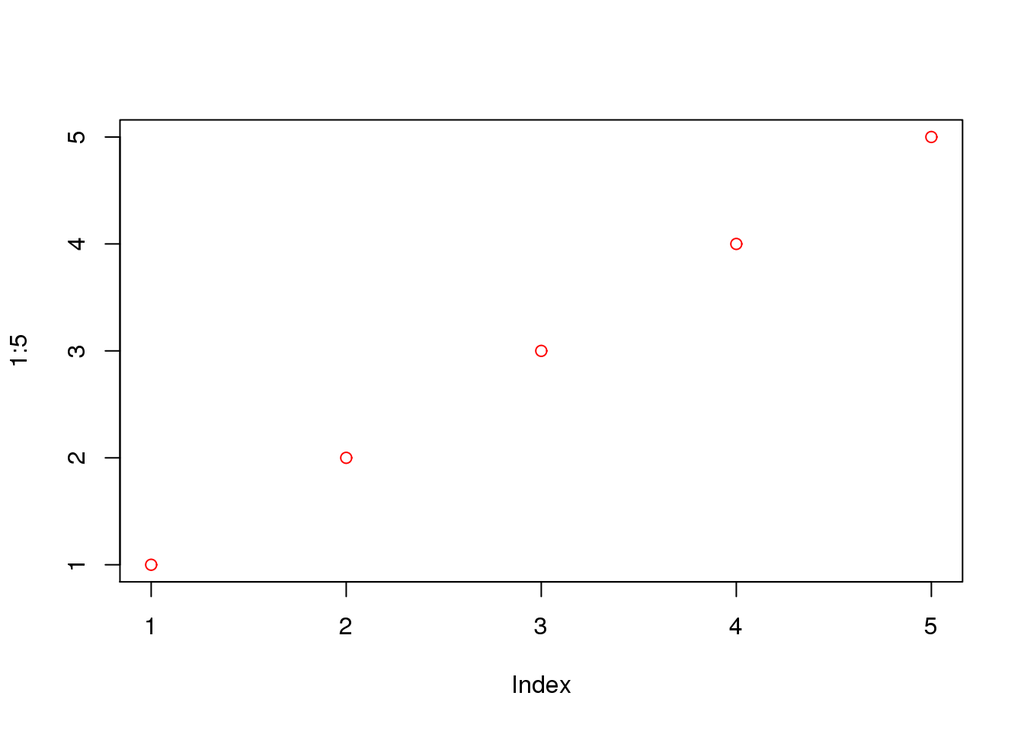

```r
plot(1:5, col = "red")
```

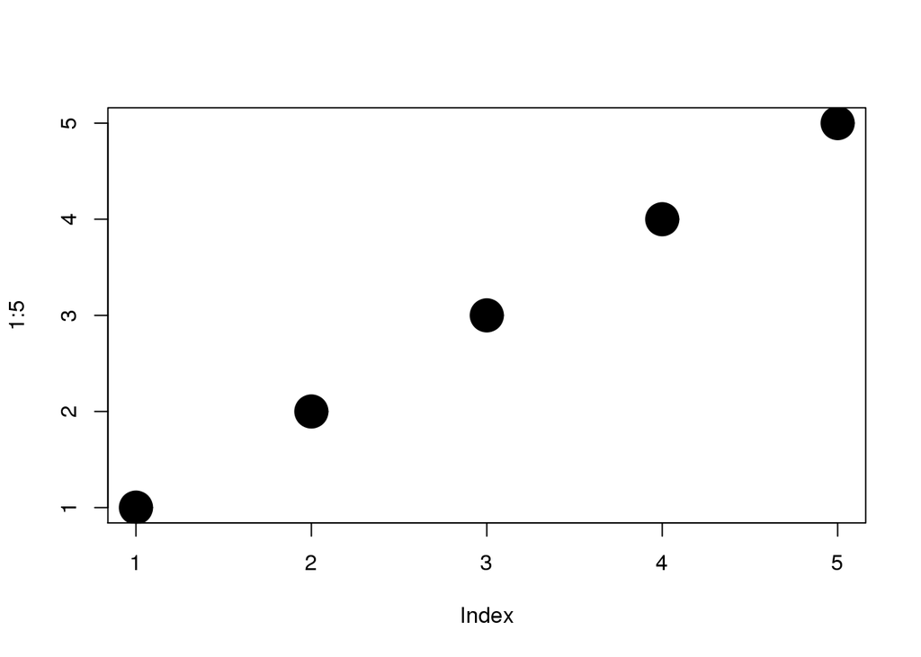

```r
plot(1:5, cex = 5, pch = 20)
```

This illustrates both the advantages and disadvantages of `...`: it makes `plot()` very flexible, but to understand how to use it, we have to carefully read the documentation. Additionally, if we read the source code for plot.default, we can discover undocumented features. It’s possible to pass along other arguments to `Axis()` and `box()`:

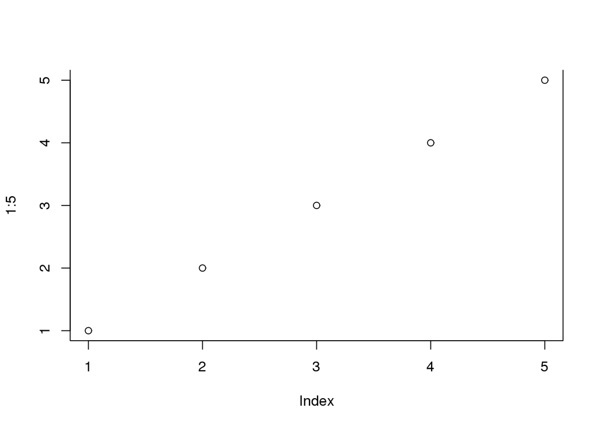

```r
plot(1:5, bty = "u")
```

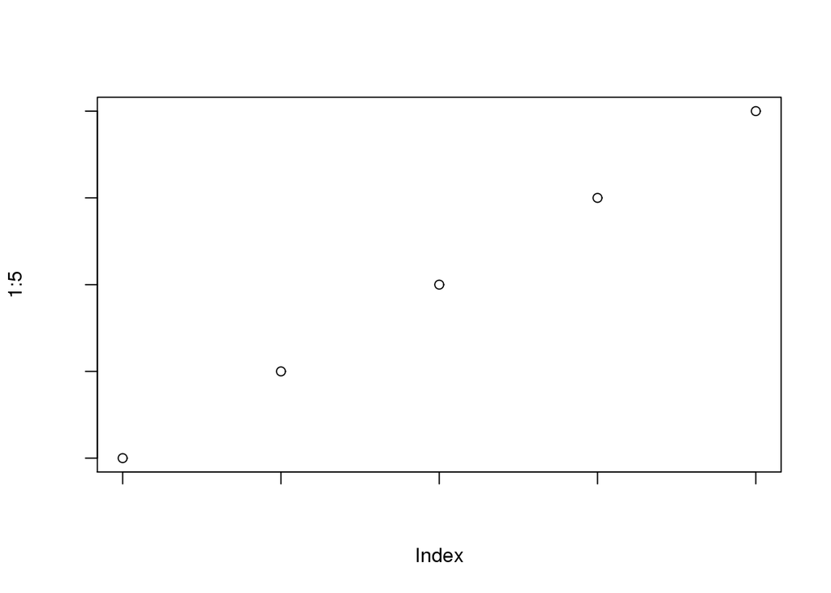

```r
plot(1:5, labels = FALSE)
```

To capture `...` in a form that is easier to work with, you can use `list(...)`.

```r
f <- function(...) {
  names(list(...))
}
f(a = 1, b = 2)
```

```
## [1] "a" "b"
```

Using `...` comes at a price—any misspelled arguments will not raise an error, and any arguments after `...` must be fully named. This makes it easy for typos to go unnoticed:

```r
sum(1, 2, NA, na.mr = TRUE)
```

```
## [1] NA
```

## 6.5 Special calls

R supports two additional syntaxes for calling special types of functions: **infix** and **replacement** functions.

### 6.5.1 Infix functions

Most functions in R are “prefix” operators: the name of the function comes before the arguments. You can also create infix functions where the function name comes in between its arguments, like `+` or `-`. All user-created infix functions must start and end with `%`. See the built-in infix functions in the text.

For example, we could create a new operator that pastes together strings:

```r
`%+%` <- function(a, b) paste0(a, b)
"new" %+% " string"
```

```
## [1] "new string"
```

Note that when creating the function, you have to put the name in backticks because it’s a special name. This is just a syntactic sugar for an ordinary function call; as far as R is concerned there is no difference between these two expressions:

```r
"new" %+% " string"
```

```
## [1] "new string"
```

```r
`%+%`("new", " string")
```

```
## [1] "new string"
```

Or:

```r
1 + 5
```

```
## [1] 6
```

```r
`+`(1, 5)
```

```
## [1] 6
```

The names of infix functions are more flexible than regular R functions: they can contain any sequence of characters (except “%”, of course). You will need to escape any special characters in the string used to define the function, but not when you call it:

```r
`% %` <- function(a, b) paste(a, b)
`%'%` <- function(a, b) paste(a, b)
`%/\\%` <- function(a, b) paste(a, b)

"a" % % "b"
```

```
## [1] "a b"
```

```r
"a" %'% "b"
```

```
## [1] "a b"
```

```r
"a" %/\% "b"
```

```
## [1] "a b"
```

R’s default precedence rules mean that infix operators are composed from left to right:

```r
`%-%` <- function(a, b) paste0("(", a, " %-% ", b, ")")
"a" %-% "b" %-% "c"
```

```
## [1] "((a %-% b) %-% c)"
```

### 6.5.2 Replacement functions

Replacement functions act like they modify their arguments in place, and have the special name `xxx<-`. They typically have two arguments (`x` and `value`), although they can have more, and they must return the modified object. For example, the following function allows you to modify the second element of a vector:

```r
`second<-` <- function(x, value) {
  x[2] <- value
  x
}
x <- 1:10
second(x) <- 5L
x
```

```
##  [1]  1  5  3  4  5  6  7  8  9 10
```

When R evaluates the assignment `second(x) <- 5`, it notices that the left hand side of the `<-` is not a simple name, so it looks for a function named `second<-` to do the replacement.

I say they “act” like they modify their arguments in place, because they actually create a modified copy. We can see that by using `pryr::address()` to find the memory address of the underlying object.

```r
library(pryr)
x <- 1:10
address(x)
```

```
## [1] "0x2f94750"
```

```r
second(x) <- 6L
address(x)
```

```
## [1] "0x3ba74f0"
```

```r
x <- 1:10
address(x)
```

```
## [1] "0x2fe4228"
```

```r
x[2] <- 7L
address(x)
```

```
## [1] "0x2fcdb70"
```

If you want to supply additional arguments, they go in between x and value:

```r
`modify<-` <- function(x, position, value) {
  x[position] <- value
  x
}
modify(x, 1) <- 10
x
```

```
##  [1] 10  7  3  4  5  6  7  8  9 10
```

When you call `modify(x, 1) <- 10`, behind the scenes R turns it into:

```r
x <- `modify<-`(x, 1, 10)
```

This means you can’t do things like:

```r
# modify(get("x"), 1) <- 10
```

because that gets turned into the invalid code:

```r
# get("x") <- `modify<-`(get("x"), 1, 10)
```

It’s often useful to combine replacement and subsetting:

```r
x <- c(a = 1, b = 2, c = 3)
names(x)
```

```
## [1] "a" "b" "c"
```

```r
names(x)[2] <- "two"
names(x)
```

```
## [1] "a"   "two" "c"
```

## 6.6 Return values

The last expression evaluated in a function becomes the return value, the result of invoking the function.

```r
f <- function(x) {
  if (x < 10) {
    0
  } else {
    10
  }
}
f(5)
```

```
## [1] 0
```

```r
f(15)
```

```
## [1] 10
```

It’s good style to reserve the use of an explicit `return()` for when you are returning early, such as for an error, or a simple case of the function.

```r
f <- function(x, y) {
  if (!x) return(y)

  # complicated processing here
}
```

Functions can return only a single object. But this is not a limitation because you can return a list containing any number of objects.

The functions that are the easiest to understand and reason about are pure functions: functions that always map the same input to the same output and have no other impact on the workspace. In other words, pure functions have no **side effects**: they don’t affect the state of the world in any way apart from the value they return.

R protects you from one type of side effect: most R objects have copy-on-modify semantics. So modifying a function argument does not change the original value:

```r
f <- function(x) {
  x$a <- 2
  x
}
x <- list(a = 1)
f(x)
```

```
## $a
## [1] 2
```

```r
x$a
```

```
## [1] 1
```

There are two important exceptions to the copy-on-modify rule: environments and reference classes. These can be modified in place, so extra care is needed when working with them.

This is notably different to languages like Java where you can modify the inputs of a function. This copy-on-modify behaviour has important performance consequences which are discussed in depth in profiling. (Note that the performance consequences are a result of R’s implementation of copy-on-modify semantics; they are not true in general. Clojure is a new language that makes extensive use of copy-on-modify semantics with limited performance consequences.)

Most base R functions are pure, with a few notable exceptions: see the text.

It’s generally a good idea to minimise the use of side effects, and where possible, to minimise the footprint of side effects by separating pure from impure functions. Pure functions are easier to test (because all you need to worry about are the input values and the output), and are less likely to work differently on different versions of R or on different platforms. For example, this is one of the motivating principles of `ggplot2`: most operations work on an object that represents a plot, and only the final print or plot call has the side effect of actually drawing the plot.

Functions can return invisible values, which are not printed out by default when you call the function.

```r
f1 <- function() 1
f2 <- function() invisible(1)

f1()
```

```
## [1] 1
```

```r
f2()
f1() == 1
```

```
## [1] TRUE
```

```r
f2() == 1
```

```
## [1] TRUE
```

You can force an invisible value to be displayed by wrapping it in parentheses:

```r
(f2())
```

```
## [1] 1
```

The most common function that returns invisibly is `<-`:

```r
a <- 2
(a <- 2)
```

```
## [1] 2
```

This is what makes it possible to assign one value to multiple variables:

```r
a <- b <- c <- d <- 2
```

because this is parsed as:

```r
(a <- (b <- (c <- (d <- 2))))
```

```
## [1] 2
```

### 6.6.1 On exit

As well as returning a value, functions can set up other triggers to occur when the function is finished using `on.exit()`. This is often used as a way to guarantee that changes to the global state are restored when the function exits. The code in `on.exit()` is run regardless of how the function exits, whether with an explicit (early) return, an error, or simply reaching the end of the function body.

```r
in_dir <- function(dir, code) {
  old <- setwd(dir)
  on.exit(setwd(old))

  force(code)
}
getwd()
```

```
## [1] "/Network/Servers/mozart.stat.wvu.edu/bayes/jharner/courses/stat523/Notes/chap6functions3"
```

```r
in_dir("~", getwd())
```

```
## [1] "/Network/Servers/mozart.stat.wvu.edu/bayes/jharner"
```

The basic pattern is simple:  
* We first set the directory to a new location, capturing the current location from the output of `setwd()`.  
* We then use `on.exit()` to ensure that the working directory is returned to the previous value regardless of how the function exits.  
* Finally, we explicitly force evaluation of the code. (We don’t actually need `force()` here, but it makes it clear to readers what we’re doing.)